# Airtable: ML Intervention

Akanimoh | AfroLogicInsect

2025-01-13

### Data Glimpse

```r
df <- airtable_df %>%
  select(-c("id_2", "id", "date_added", "created_time")) %>%
  filter((age - years_of_experience) > 18) %>%
  as.tibble()

glimpse(df)
```

```
## Rows: 1,103
## Columns: 9
## $ phone               <chr> "957-474-8982", "001-606-273-4942x7284", "+1-964-2…
## $ address             <chr> "921 Henry Pass Apt. 227\\nWilliamsshire, IA 45370…
## $ department          <chr> "Sales", "Marketing", "Operations", "Engineering",…
## $ salary              <dbl> 145111.61, 130286.02, 31026.68, 114910.77, 98847.0…
## $ name                <chr> "Linda Schneider", "Matthew Graham", "Stacey Walla…
## $ status              <chr> "On Leave", "Active", "Remote", "Contract", "Contr…
## $ email               <chr> "elizabeththomas@example.net", "amy39@example.com"…
## $ years_of_experience <int> 25, 1, 36, 0, 31, 26, 45, 0, 37, 20, 36, 27, 24, 3…
## $ age                 <int> 74, 80, 63, 41, 59, 64, 72, 79, 63, 77, 59, 79, 57…
```

## Exploratory Data Analysis

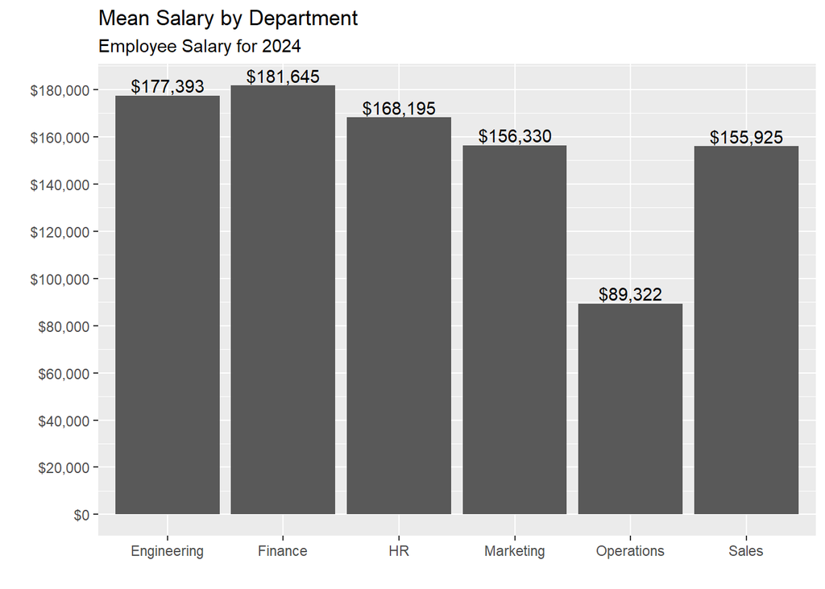

```r
## Distribution by departments
plotdata <- df %>%
  group_by(department) %>%
  summarize(avg_salary = mean(salary))

plotdata %>%
  ggplot(aes(x=department, y=avg_salary)) +
  geom_bar(stat = "identity") +
  geom_text(aes(label = dollar(avg_salary)),
            vjust = -0.25) +
  scale_y_continuous(breaks = seq(0, 200000, 20000),
                     label = dollar) +
  labs(title = "Mean Salary by Department",
       subtitle = "Employee Salary for 2024",
       x = "",
       y = "")
```

- Engineering: $177392.66
- Finance: $181645.04
- HR: $168195.3
- Marketing: $156329.86
- Operations: $89322.24
- Sales: $155924.95

From this chart, we can see that the Finance department has the highest average salary, followed closely by Engineering. Operations has the lowest average salary among the departments listed. This comparison can be useful for understanding salary disparities and making informed decisions about salary adjustments or career choices.

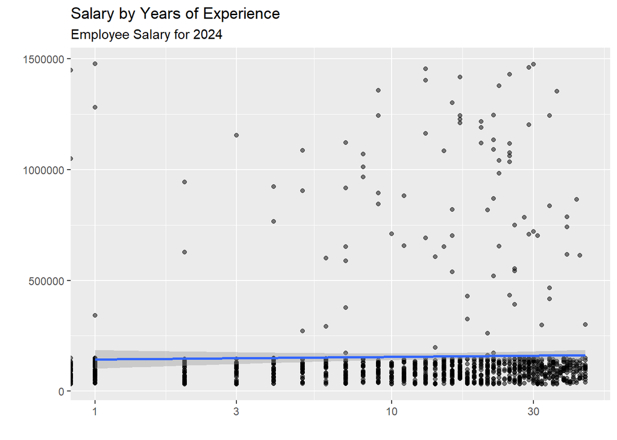

```r
## Distribution by Years of Experience
df %>%
  ggplot(aes(x=years_of_experience , y=salary)) +
  geom_point(alpha = 0.5) +
  scale_x_log10() +
  scale_color_viridis_c() +
  geom_smooth(method = "lm") +
  labs(title = "Salary by Years of Experience",
       subtitle = "Employee Salary for 2024",
       x = "",
       y = "")
```

This scatter plot shows the relationship between employees’ salaries and their years of experience.

The Smoothing Line: Indicates the trend of the data.